# UGR Tema 3

franmarq@gmail.com

2022-11-30

```r
library(geoR)
library(fields)
```

En primer lugar llemos la data de trabajo

```r
datany <- read.csv('NY_schools.csv', header = T)
str(datany)
```

```
## 'data.frame':    479 obs. of  30 variables:
##  $ DBN                                 : chr  "01M292" "01M448" "01M450" "01M458" ...
##  $ school_name                         : chr  "HENRY STREET SCHOOL FOR INTERNATIONAL STUDIES" "UNIVERSITY NEIGHBORHOOD HIGH SCHOOL" "EAST SIDE COMMUNITY SCHOOL" "FORSYTH SATELLITE ACADEMY" ...
##  $ Num.of.SAT.Test.Takers              : int  29 91 70 7 44 112 159 18 130 16 ...
##  $ SAT.Critical.Reading.Avg..Score     : int  355 383 377 414 390 332 522 417 624 395 ...
##  $ SAT.Math.Avg..Score                 : int  404 423 402 401 433 557 574 418 604 400 ...
##  $ SAT.Writing.Avg..Score              : int  363 366 370 359 384 316 525 411 628 387 ...
##  $ avg_sat_score                       : int  1122 1172 1149 1174 1207 1205 1621 1246 1856 1182 ...
##  $ AP.Test.Takers                      : num  2.5 39 19 2.5 2.5 24 255 2.5 2.5 2.5 ...
##  $ Total.Exams.Taken                   : int  NA 49 21 NA NA 26 377 NA NA NA ...
##  $ Number.of.Exams.with.scores.3.4.or.5: int  NA 10 NA NA NA 24 191 NA NA NA ...
##  $ exams_per_student                   : num  NA 1.26 1.11 NA NA ...
##  $ high_score_percent                  : num  NA 20.4 NA NA NA ...
##  $ avg_class_size                      : int  23 22 21 23 24 23 26 22 21 16 ...
##  $ frl_percent                         : num  88.6 71.8 71.8 72.8 80.7 NA 23 69.8 18 66.9 ...
```

[output cut: 16 more lines]

```r
datany2 <- datany[,c(5,29,30)]
str(datany2)
```

```
## 'data.frame':    479 obs. of  3 variables:
##  $ SAT.Math.Avg..Score: int  404 423 402 401 433 557 574 418 604 400 ...
##  $ lat                : num  40.7 40.7 40.7 NA 40.7 ...
##  $ long               : num  -74 -74 -74 NA -74 ...
```

```r
datanygeo <- as.geodata(datany2,coords.col = 2:3,data.col = 1, data.names = NULL)
```

```
## as.geodata: 120 replicated data locations found.
##  Consider using jitterDupCoords() for jittering replicated locations.
## WARNING: there are data at coincident or very closed locations, some of the geoR's functions may not work.
##  Use function dup.coords() to locate duplicated coordinates.
##  Consider using jitterDupCoords() for jittering replicated locations
```

```r
names(datanygeo)
```

```
## $coords
## [1] "lat"  "long"
##
## $data
## [1] "data"
```

```r
str(datanygeo)
```

```
## List of 2
##  $ lat             , long            : num [1:340, 1:2] 40.7 40.7 40.7 40.7 40.7 ...
##   ..- attr(*, "dimnames")=List of 2
##   .. ..$ : chr [1:340] "1" "2" "3" "5" ...
##   .. ..$ : chr [1:2] "lat" "long"
##  $ data            : int [1:340] 404 423 402 433 574 604 400 393 384 375 ...
##  - attr(*, "class")= chr "geodata"
```

```r
data(datanygeo)
summary(datanygeo)
```

```
## Number of data points: 340
##
## Coordinates summary
##          lat      long
## min 40.52823 -74.19215
## max 40.88837 -73.72691
##
## Distance summary
##       min       max
## 0.0000000 0.5132254
##
## Data summary
##     Min.  1st Qu.   Median     Mean  3rd Qu.     Max.
## 312.0000 376.7500 401.0000 419.9353 445.2500 735.0000
##
```

[output cut: 181 more lines]

De la data original, tomamos la variables: longitud, latitud y ScoreSatMatematica. Y creamos el conjunto de datos spaciales datanygeo. A continuación generamos graficos que nos describen las caracteríticas principales de los datos.

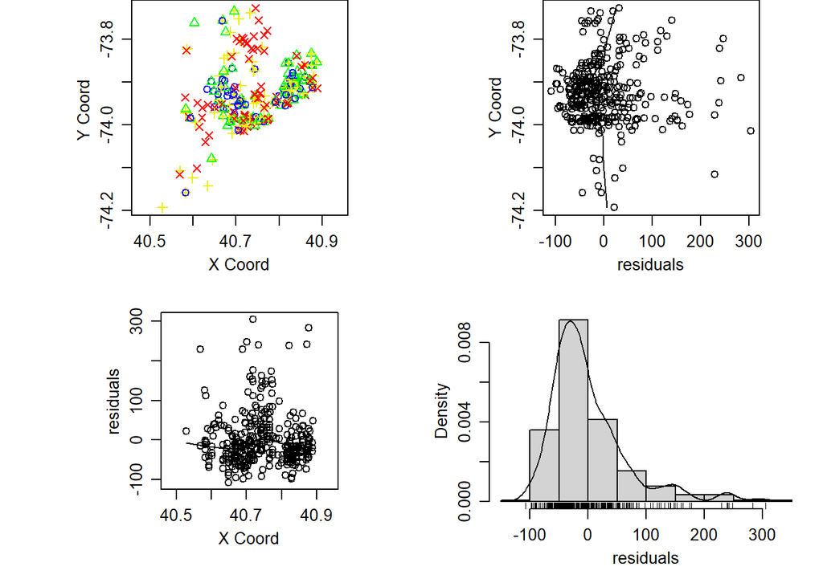

```r
plot(datanygeo, trend = "1st", lowess=TRUE)
```

A continuación generamos un gráfico, similar a una imagen donde las ubicaciones se discretizan en una cuadrícula, dado un vector de valores z de la variable resultado (score) asociados con ubicaciones bidimensionales los valores z se codifican como un nivel de color de una escala de color.

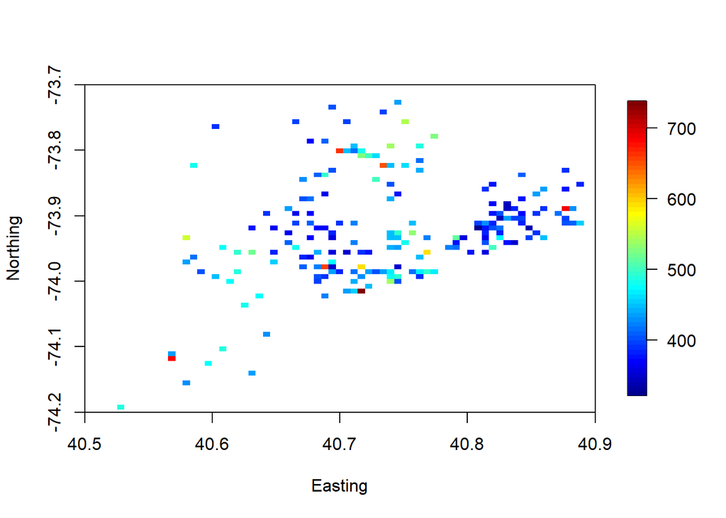

```r
quilt.plot(datanygeo$coords, datanygeo$data, ny = ,
           ylim = c(-74.2, -73.7),
           xlim = c(40.5, 40.9), xlab = "Easting", ylab = "Northing")
```

Variogramas empíricos

```r
par(mfrow = c(1, 2), las = 1)

cloud1 <- variog(datanygeo, option = "cloud", max.dist=1)
```

```
## variog: computing omnidirectional variogram
## variog: co-locatted data found, adding one bin at the origin
```

```r
bin1 <- variog(datanygeo, uvec=seq(0,1,l=11))
```

```
## variog: computing omnidirectional variogram
## variog: co-locatted data found, adding one bin at the origin
```

```r
plot(cloud1, main = "Estimator clasico")

#plot(bin1, main = "classical estimator")
datanygeo.vario <- variog(datanygeo, max.dist = 1)
```

```
## variog: computing omnidirectional variogram
## variog: co-locatted data found, adding one bin at the origin
```

```r
#plot(datanygeo.vario)
datanygeo.variot <- variog(datanygeo, trend = "1st",  max.dist = 1)
```

```
## variog: computing omnidirectional variogram
## variog: co-locatted data found, adding one bin at the origin
```

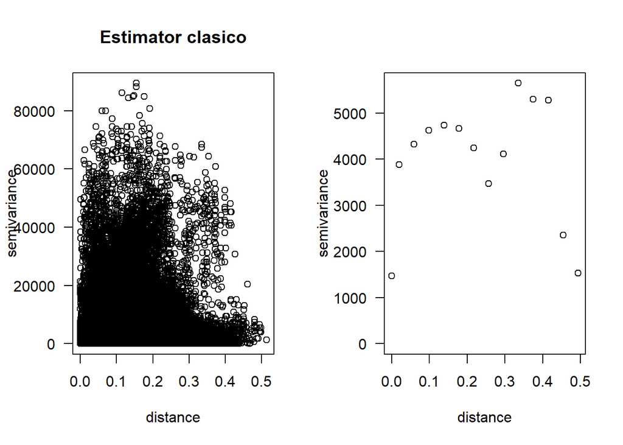

```r
plot(datanygeo.variot)
```

Adicionalmente, los puntos de las nubes de variograma se pueden agrupar en clases de distancias (“contenedores”) y mostrarse con un diagrama de caja para cada contenedor.

```r
bin1 <- variog(datanygeo,uvec = seq(0,1,l=11), bin.cloud = T)
```

```
## variog: computing omnidirectional variogram
## variog: co-locatted data found, adding one bin at the origin
```

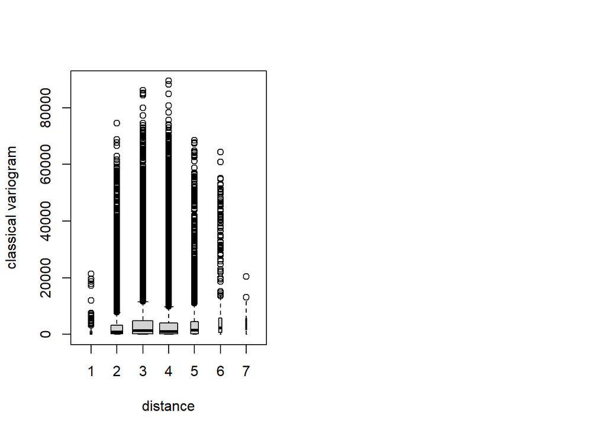

```r
par(mfrow = c(1,2))
plot(bin1, bin.cloud = T, main = "Estimator clasico")
```

```r
bin1 <- variog(datanygeo, uvec = seq(0,1,l=100))
```

```
## variog: computing omnidirectional variogram
## variog: co-locatted data found, adding one bin at the origin
```

```r
plot(bin1)
lines.variomodel(cov.model = "exp", cov.pars = c(8000,0.3), nugget = 0, max.dist = 1,  lwd = 3)
smooth <- variog(datanygeo, option = "smooth", max.dist = 1, n.points = 400, kernel = "normal", band = 0.15)
```

```
## variog: computing omnidirectional variogram
## variog: co-locatted data found, adding one bin at the origin
```

[figure not shown]

```r
lines(smooth, type ="l", lty = 2)
legend(0.01, 10000, c("empirico", "suavizado"), lty = c(1,1,2), lwd = c(1,3,1))
```

Ajuste de Variogramas teoricos Minimos cuadrados

a continuación se muestra como podemos agregar una línea con un modelo de variograma a una gráfica de variograma.

```r
plot(variog(datanygeo, max.dist=1))
```

```
## variog: computing omnidirectional variogram
## variog: co-locatted data found, adding one bin at the origin
```

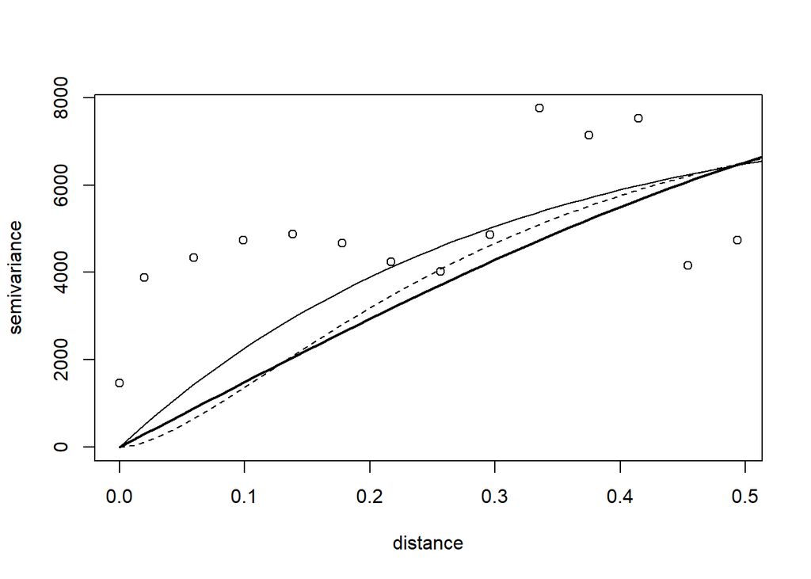

```r
lines.variomodel(cov.model="exp", cov.pars=c(8000,.3), nug=0, max.dist=1)
lines.variomodel(cov.model="mat", cov.pars=c(8000,.2), nug=0.1, kappa=1,max.dist=1, lty=2)
lines.variomodel(cov.model="sph", cov.pars=c(8000,.8), nug=0.1,max.dist=1, lwd=2)
```

```r
# sin tendencia espacial
datanygeo.vfit.exp <- variofit(datanygeo.vario)
```

```
## variofit: covariance model used is matern
## variofit: weights used: npairs
## variofit: minimisation function used: optim
```

```
## variofit: searching for best initial value ... selected values:
##               sigmasq   phi   tausq    kappa
## initial.value "3877.71" "0"   "775.54" "0.5"
## status        "est"     "est" "est"    "fix"
## loss value: 17869646153.811
```

```r
datanygeo.vfit.mat1.5  <- variofit(datanygeo.vario, kappa = 1.5)
```

```
## variofit: covariance model used is matern
## variofit: weights used: npairs
## variofit: minimisation function used: optim
```

```
## variofit: searching for best initial value ... selected values:
##               sigmasq   phi   tausq    kappa
## initial.value "3877.71" "0"   "775.54" "1.5"
## status        "est"     "est" "est"    "fix"
## loss value: 17869646153.811
```

```r
datanygeo.vfit.sph  <- variofit(datanygeo.vario, cov.model = "sph")
```

```
## variofit: covariance model used is spherical
## variofit: weights used: npairs
## variofit: minimisation function used: optim
```

```
## variofit: searching for best initial value ... selected values:
##               sigmasq   phi   tausq    kappa
## initial.value "3877.71" "0"   "775.54" "0.5"
## status        "est"     "est" "est"    "fix"
## loss value: 17869646153.811
```

```r
# con tendencia lineal
#datanygeo.vtfit.exp <- variofit(datanygeo.variot)
#datanygeo.vtfit.mat1.5  <- variofit(datanygeo.variot, kappa = 1.5)
#datanygeo.vtfit.sph  <- variofit(datanygeo.variot, cov.model = "sph")
```

Graficamos el resultado del ajuste de estos modelos

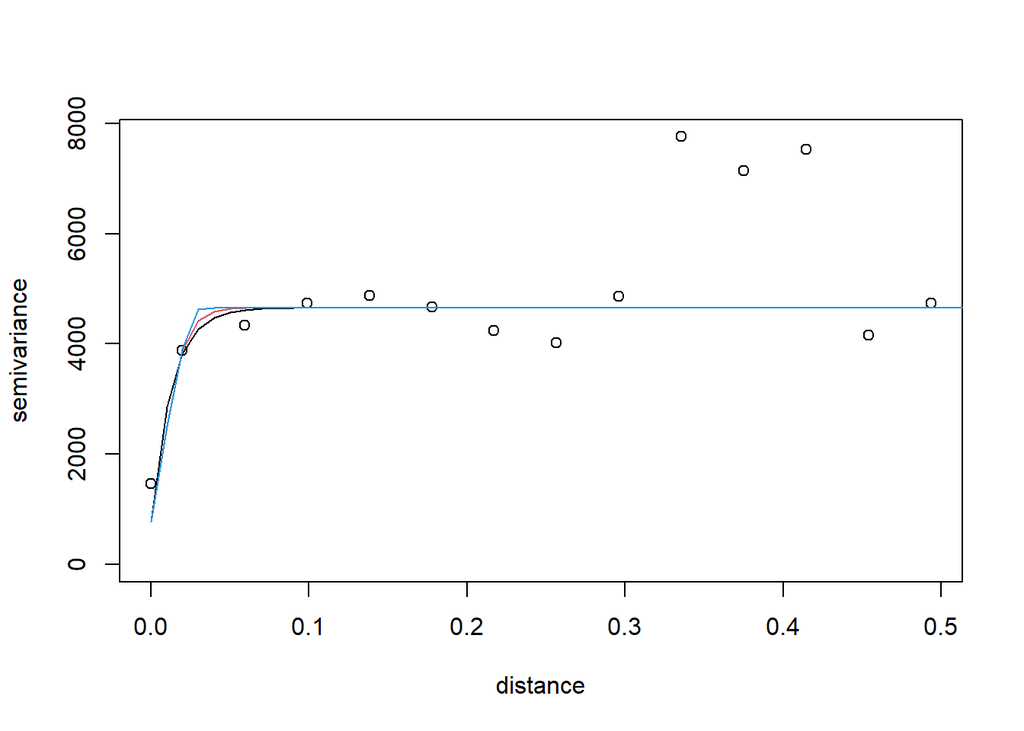

```r
#par(mfrow = c(1, 2))
plot(datanygeo.vario)
lines(datanygeo.vfit.exp); lines(datanygeo.vfit.mat1.5, col = 2); lines(datanygeo.vfit.sph, col = 4)
```

```r
#plot(datanygeo.variot)
#lines(datanygeo.vtfit.exp); lines(datanygeo.vtfit.mat1.5, col = 2); lines(datanygeo.vtfit.sph, col = 4)
```

Mapa de Interpolacion

consideremos la predicción en cuatro ubicaciones etiquetadas con 1, 2, 3, 4 e indicadas a continuación.

```r
loci <- matrix(c(40, 40.1, 40.2, 40.3, 40.7, 40.8, 40.9, 41), ncol=2)

kc4 <- krige.conv(datanygeo, locations = loci, krige = krige.control(obj.m = datanygeo.vfit.exp))
```

```
## krige.conv: model with constant mean
```

```
## krige.conv: Kriging performed using global neighbourhood
```

```r
print("Valores predichos")
```

```
## [1] "Valores predichos"
```

```r
kc4$predict
```

```
## [1] 437.0036 437.0036 437.0036 437.0036
```

```r
print("Varianza kriging")
```

```
## [1] "Varianza kriging"
```

```r
kc4$krige.var
```

```
## [1] 4724.724 4724.724 4724.724 4724.724
```